# Product Security Ambassadors

Osman Esquivel and Ignacio Lopez

October 20<sup>th</sup>, 2022

# Product Security Ambassadors

## Product Security Champions who represent a team/region, as opposed to an application

## MXC Office

- Osman Esquivel
- Ignacio Lopez

## Shanghai Office

- Mike Xu

## Deployment

- Ed Southgate

## More PSA to be added

- QE team

# What do they do?

- Spread awareness of product security among development teams
- Share product security resources and information
- Gather feedback from development teams/regions regarding product security
- Auxiliary support in product security activities

# Our Current Activities

## 1. Product Security Council meetings

## 2. Automation of SAST (Appscan)

- A utility to setup and run a scheduled SAST (appscan scanning)
- Documentation
- Support as needed

## 3. Help testing the new signing tool for the CI/CD pipeline

- Using digest signing

# Why security matters?

[Cyber Security At its Best in 5 min](https://youtu.be/B6dZWe7eOpA)

- Minimize the risk
- You are as secure as your weakest link
- Fundamental to adopt strong security practices to avoid security breaches

## There is a cultural shift in Cybersecurity

- Customers and government are raising expectations for cybersecurity
- Increased expectations on disclosure and visibility
- We need to adjust our processes and activities to meet these new expectations

# Essential for security

## Grow the security culture

# Security Champion

- Leadership + Mindset + Skill Set
- Handles the relation between its team and the security team
- Does security reviews
- They need to be interested in security
- Collaborative
- Good communicator
- Help keep everybody on target

# Evolving Security Champions Roles

## New specialized roles

- Benefits / Purpose
  - Scale Up
  - Maturity

## Roles based on

- Skills
- Interests
- Needs

# Proposed new roles

## Risk Engineers (PSC roles)

- Help review final version of Policy, Procedures, and Guidelines
- Threat modeling
- SAST scanning
- Security Defects
- Culture push

## Product Security Ambassadors

- Represent a region
- Provide feedback, policies, guidelines
- Work on larger-scale initiatives
- Will be supporting if there are considerations for the team they represent

## Security Practitioners

- Assist in the development of security patterns and best practices
- Assist in deeper dives into security technical issues
- May be asked to help with Security Requirements
  - Definition of controls and when to apply them
  - How to apply for different technologies or product context

## CI/CD → Continuous Integration / Continuous Deployment

### (Checking in code and continuous building)

- It was emphasized on delivery not security
- DevOps teams may lack security knowledge
- Traditional automated testing does not focus on Security Testing
- Figure out the risk of the libraries on our applications

## OWASP

- Tools must be integrated into the pipeline
- Tools must not require security expertise
- Tools result must be accurate and important
- Engineers must have high confidence that fixing issues won’t break other things

# Security Development Lifecycle (SDL)

- Set of practices that support security assurance and compliance requirements
- Help developers build more secure software
  - By reducing the number and severity of vulnerabilities
  - While reducing development cost

# SDL Timeline

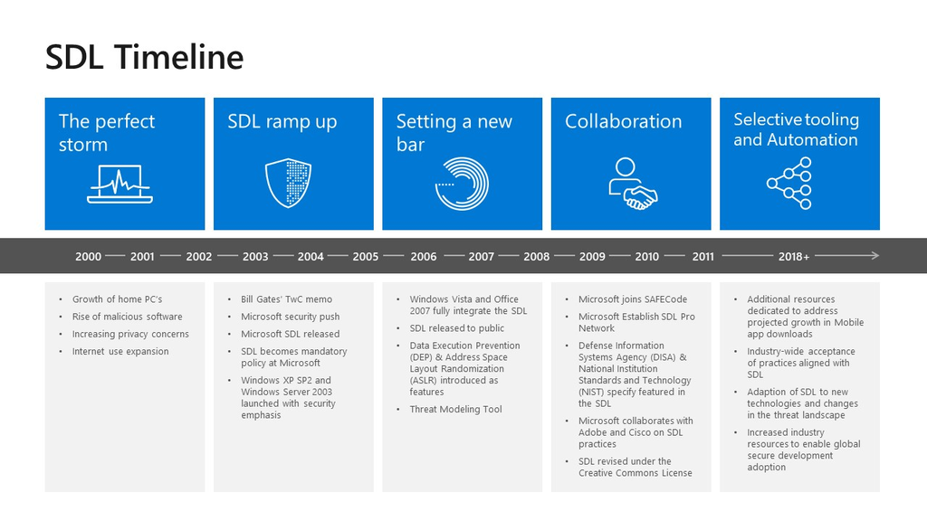

*Source: [About Microsoft SDL, Microsoft 2022](https://www.microsoft.com/en-us/securityengineering/sdl/about)*

# Aspentech’s SDL

[figure not shown]

## How to write secure code?

- For C++ first thing to do is:
  - Does your code compile with zero warnings?
  - Prevent people from using bad methods.
  - We may be vulnerable with a buffer overflow

# SDL Practices

- Provide security training (at least one a year on different things)
  - DevOps
  - Data
  - Social Engineering
- Cryptographic standards
- Threat modeling
- Establish a standard incident response process

[figure not shown]

## Social Engineering

- Phishing
- Pretexting
- Baiting
- Quid Pro Quo
- Tailgating

# High-Profile Security Breaches

[figure not shown]

# How are we doing?

- Understand what components make up your application
  - Purchased 3rd Party
  - OSS
- Licensing requirements
  - Apache 2.0
  - GPL is a security risk to the company

## It can make our IP public!

[figure not shown]